# Cox Proportional Hazards Model

Author

Lianghui Yi

## Introduction

- **Why Use the Cox Proportional Hazards Model?**
  - It evaluates the relationship between survival time and covariates without assuming a specific baseline hazard function.
  - Allows adjustment for confounding variables such as demographic, biomarkers and clinical characteristics.
- **Primary Objective**:
  - To compare PFS between two treatment groups while adjusting for potential confounding factors.
- **Secondary Objectives**:
  - Visualize adjusted survival probabilities to clarify treatment effects.
  - Verify model assumptions using Cox-Snell residuals to ensure validity.

## Read in the Data

```r
# 1. Read in the data
data <- read.csv("../data/derived-data/PFS_Merged_Cleaned_factored.csv")
# drop NA values
data <- na.omit(data)
# get shape of data
head(data)
```

A data.frame: 6 x 28

|  | X <int> | STUDYID <chr> | USUBJID <chr> | CNSR <int> | TRT01P <chr> | PPROTFL <chr> | STARTDT <chr> | ADT <chr> | AVAL <int> | EVNTDESC <chr> | ... | RACE <chr> | ETHNIC <chr> | LDH <dbl> | ALB <dbl> | HGB <dbl> | EXTRT <chr> | EXDOSE <int> | BMI <dbl> | ECOG <int> | CRP <dbl> |
| --- | --- | --- | --- | --- | --- | --- | --- | --- | --- | --- | --- | --- | --- | --- | --- | --- | --- | --- | --- | --- | --- |
| 1 | 1 | 54767414MMY3008 | SUBJ0001 | 0 | TREAT A | Y | 2019-04-22 | 2021-01-12 | 631 | DEATH | ... | White | Not Hispanic or Latino | 139.7219 | 155.2226 | 135.7905 | Dexamethasone | 110 | 26.83260 | 4 | 12.830053 |
| 2 | 2 | 54767414MMY3008 | SUBJ0002 | 0 | TREAT A | Y | 2021-10-13 | 2024-04-04 | 904 | DEATH | ... | White | Not Hispanic or Latino | 115.6110 | 128.2108 | 131.7716 | Daratumumab | 30 | 25.42065 | 1 | 6.702462 |
| 4 | 4 | 54767414MMY3008 | SUBJ0004 | 1 | TREAT A | Y | 2020-12-31 | 2021-09-25 | 268 | ANALYSIS CUT OFF | ... | White | Not Hispanic or Latino | 144.8748 | 171.4453 | 129.9159 | Lenalidomide | 150 | 22.04537 | 1 | 2.101916 |
| 5 | 5 | 54767414MMY3008 | SUBJ0005 | 1 | TREAT A | Y | 2017-10-26 | 2018-07-13 | 260 | LAST CONTACT | ... | White | Not Hispanic or Latino | 161.9881 | 131.3127 | 164.3331 | Daratumumab | 130 | 20.38940 | 1 | 7.230141 |
| 6 | 6 | 54767414MMY3008 | SUBJ0006 | 0 | TREAT B | Y | 2017-02-02 | 2017-12-13 | 314 | DEATH | ... | White | Not Hispanic or Latino | 175.1388 | 141.2525 | 159.1366 | Lenalidomide | 20 | 21.33275 | 1 | 6.671318 |
| 7 | 7 | 54767414MMY3008 | SUBJ0007 | 0 | TREAT A | Y | 2019-10-02 | 2020-09-13 | 347 | DEATH | ... | White | Hispanic or Latino | 105.8889 | 156.4769 | 156.2880 | Daratumumab | 170 | 26.86364 | 4 | 12.715051 |

```r
# Load Library
library(survival)
library(survminer)
library(ggplot2)
library(dplyr)

# Prepare the data
# CNSR: Event indicator (0 = event occurred, 1 = censored)
data$CNSR <- as.numeric(data$CNSR)
# AVAL: Time to event
data$AVAL <- as.numeric(data$AVAL)
# TRT01P: Treatment Method
data$TRT01P <- as.factor(data$TRT01P)
```

## Feature Selection

```r
selected_columns <- c("TRT01P", "ECOG", "HGB", "TOTAE", "SEX")
# selected_columns <- c("TOTAE", "ETHNIC")
selected_columns

# convert the selected columns to a formula
formula <- as.formula(
  paste("Surv(AVAL, 1-CNSR) ~", paste(selected_columns, collapse = "+"))
)
```

1. 'TRT01P'

2. 'ECOG'

3. 'HGB'

4. 'TOTAE'

5. 'SEX'

## Fitting the Cox Proportional Hazards Model

```r
# Fit the Cox model
cox_model <- coxph(
  formula,
  data = data
)
```

## Getting Summary Statistics

```r
# Summary of the model
summary(cox_model)
```

```
Call:
coxph(formula = formula, data = data)

  n= 595, number of events= 411

                    coef  exp(coef)   se(coef)      z Pr(>|z|)
TRT01PTREAT B  0.0790402  1.0822479  0.0996441  0.793   0.4276
ECOG          -0.0022992  0.9977035  0.0349379 -0.066   0.9475
HGB           -0.0008485  0.9991519  0.0007566 -1.121   0.2621
TOTAE          0.0761859  1.0791631  0.0354358  2.150   0.0316 *
SEXMale        0.0871498  1.0910602  0.1007719  0.865   0.3871
---
Signif. codes:  0 '***' 0.001 '**' 0.01 '*' 0.05 '.' 0.1 ' ' 1

              exp(coef) exp(-coef) lower .95 upper .95
TRT01PTREAT B    1.0822     0.9240    0.8902     1.316
ECOG             0.9977     1.0023    0.9317     1.068
HGB              0.9992     1.0008    0.9977     1.001
TOTAE            1.0792     0.9266    1.0068     1.157
SEXMale          1.0911     0.9165    0.8955     1.329

Concordance= 0.521  (se = 0.017 )
Likelihood ratio test= 6.86  on 5 df,   p=0.2
Wald test            = 6.95  on 5 df,   p=0.2
Score (logrank) test = 6.95  on 5 df,   p=0.2
```

## Model Summary Interpretation

### Coefficients

- A positive coefficient suggests that the hazard increases with the covariate (e.g., higher TOTAE is associated with higher risk).
- A negative coefficient suggests that the hazard decreases with the covariate (e.g., one treatment plan may reduces risk).

### Concordance Index (C-Index)

The concordance statistic (C-index) measures the model’s predictive accuracy: Values range from 0.5 (no predictive ability) to 1.0 (perfect prediction).

### Visualize the proportional hazards assumption check

This computes the Schoenfeld residuals for the Cox model to test whether the proportional hazards assumption holds for each covariate.

The test evaluates if the effect of each covariate on the hazard ratio changes over time.

A significant change indicates a violation of the proportional hazards assumption.

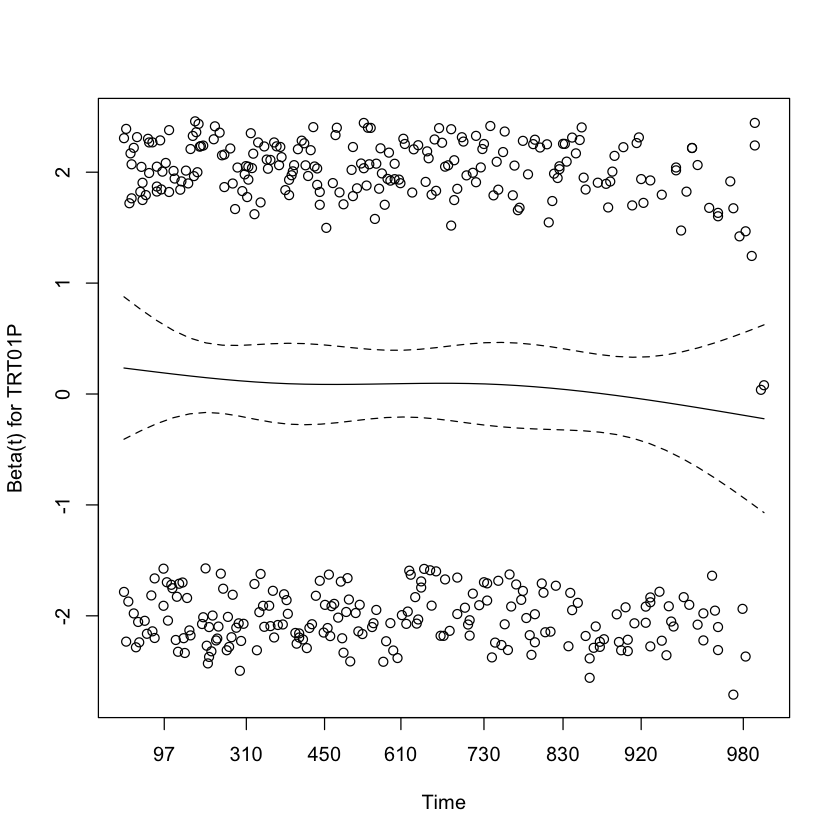

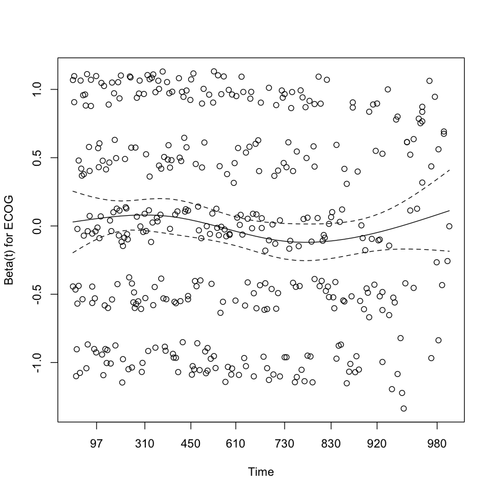

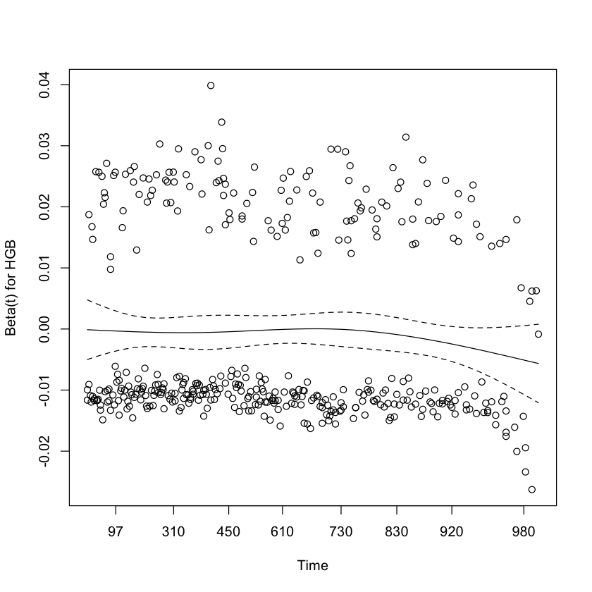

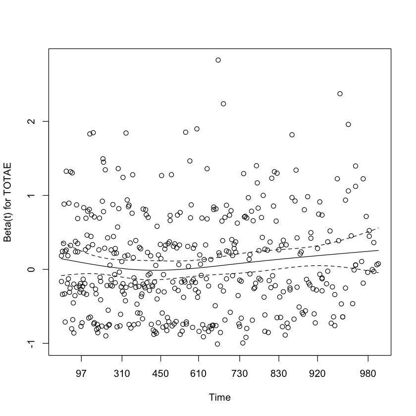

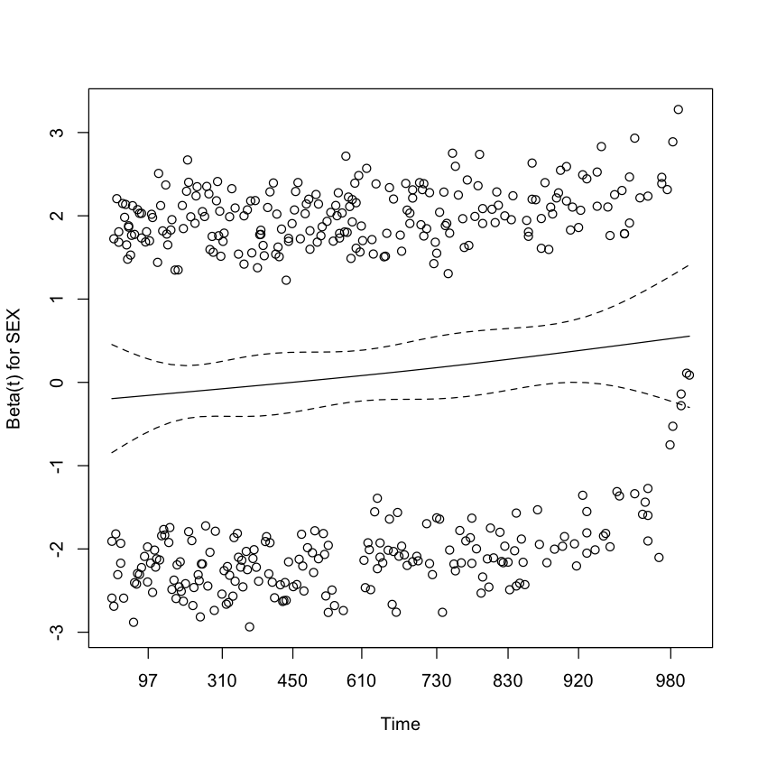

```r
plot(cox.zph(cox_model))
```

Key Points to Look For

1. Flat Line at 0: Suggests the proportional hazards assumption holds.
2. Upward/Downward Trends: Indicates potential time-varying effects of the covariate, violating the proportional hazards assumption.
3. Random Fluctuations: Small random fluctuations around 0 are normal and not concerning.

Follow-Up Actions if Assumption is Violated

If a covariate shows a significant violation: 1. Time-Dependent Covariates: Consider modeling the covariate as time-dependent (e.g., using interaction terms or tt() in coxph). 2. Stratification: Use stratified Cox models (strata()) to handle covariates that violate the proportional hazards assumption. 3. Alternative Models: Consider other survival models, such as the accelerated failure time (AFT) model.

### Doing Adjusted Survival Curves

Adjusted survival curves are used in Cox proportional hazards models to visualize the survival probabilities while accounting for the effects of covariates. They present survival estimates that are adjusted for the average or specific values of covariates, allowing a more accurate comparison between groups (e.g., treatment groups).

```r
# Fix Covarites
# Plot the adjusted survival curves for specific predictors:
# generated new data with the features set as the mean of the data other than TRT01P
newdata <- data.frame(
  TRT01P = c("TREAT A", "TREAT B"),
  TOTAE = mean(data$TOTAE, na.rm = TRUE),
  LDH = mean(data$LDH),
  ECOG = mean(data$ECOG),
  ALB = mean(data$ALB),
  HGB = mean(data$HGB),
  # get the most common value of SEX
  SEX = names(sort(table(data$SEX), decreasing = TRUE))[1]
)
newdata
```

A data.frame: 2 x 7

| TRT01P <chr> | TOTAE <dbl> | LDH <dbl> | ECOG <dbl> | ALB <dbl> | HGB <dbl> | SEX <chr> |
| --- | --- | --- | --- | --- | --- | --- |
| TREAT A | 2.462185 | 56.09367 | 2.030252 | 56.42446 | 54.72755 | Male |
| TREAT B | 2.462185 | 56.09367 | 2.030252 | 56.42446 | 54.72755 | Male |

```r
#  compute survival probabilities for the levels of your predictor of interes
surv_curves <- survfit(cox_model, newdata = newdata)
```

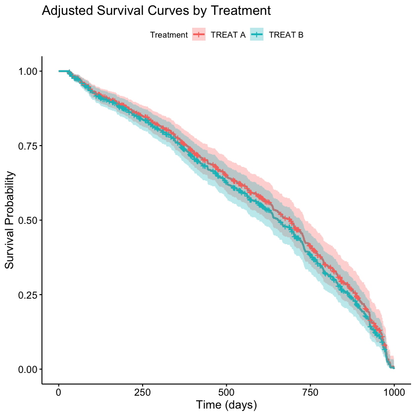

```r
## Plot the Adjusted Survival Curves
ggsurvplot(
  surv_curves,
  data = data,
  conf.int = TRUE,               # Add confidence intervals
  legend.title = "Treatment",    # Title for the legend
  legend.labs = c("TREAT A", "TREAT B"),  # Labels for levels of treatment
  xlab = "Time (days)",
  ylab = "Survival Probability",
  title = "Adjusted Survival Curves by Treatment"
)
```

```r
### ADD AIC Score Calculation

# Calculate the AIC score

aic <- AIC(cox_model)
aic
```

4379.89116625287

## Checking the fit of the model by doing Residual analysis

Cox-Snell residuals are used to assess the goodness-of-fit of a Cox proportional hazards model. The residuals provide insight into how well the model fits the data by comparing the observed survival to the expected survival under the fitted model.

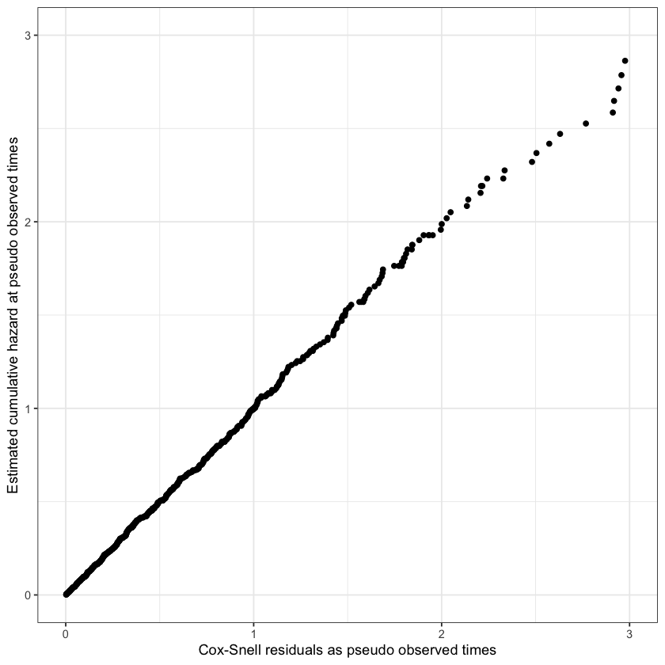

```r
data$resid_mart <- residuals(cox_model, type = "martingale")
data$resid_coxsnell <- -(data$resid_mart - (1 - data$CNSR))
fit_coxsnell <- coxph(
  formula = Surv(resid_coxsnell, (1 - CNSR)) ~ 1,
  data = data,
  ties = c("efron", "breslow", "exact")[1]
)

df_base_haz <- basehaz(fit_coxsnell, centered = FALSE)
ggplot(data = df_base_haz, mapping = aes(x = time, y = hazard)) +
    geom_point() +
    scale_x_continuous(limit = c(0,3)) +
    scale_y_continuous(limit = c(0,3)) +
    labs(x = "Cox-Snell residuals as pseudo observed times",
         y = "Estimated cumulative hazard at pseudo observed times") +
    theme_bw() + theme(legend.key = element_blank())
```